# Week Two Assignment Two

### mean and median of steps per day

assign2meanmed<-ddply(assign2,c(“date”), summarize, mean.steps=mean(steps,na.rm=TRUE), median.steps=median(steps,na.rm=TRUE))

```
##         date mean.steps median.steps
## 1 2012-10-01        NaN           NA
## 2 2012-10-02    0.43750            0
## 3 2012-10-03   39.41667            0
## 4 2012-10-04   42.06944            0
## 5 2012-10-05   46.15972            0
## 6 2012-10-06   53.54167            0
```

I have included a header of the output This shows that I was unable to calculate the median correctly

### time series plot of average time of steps taken

assign2mean<-ddply(assign2,c(“interval”),summarize,mean.steps=mean(steps,na.rm=TRUE)) p<-ggplot(assign2mean,aes(x=interval,y=mean.steps,xlab=“5 min Intervals”,ylab=“Average number of steps”)) p+geom_line()

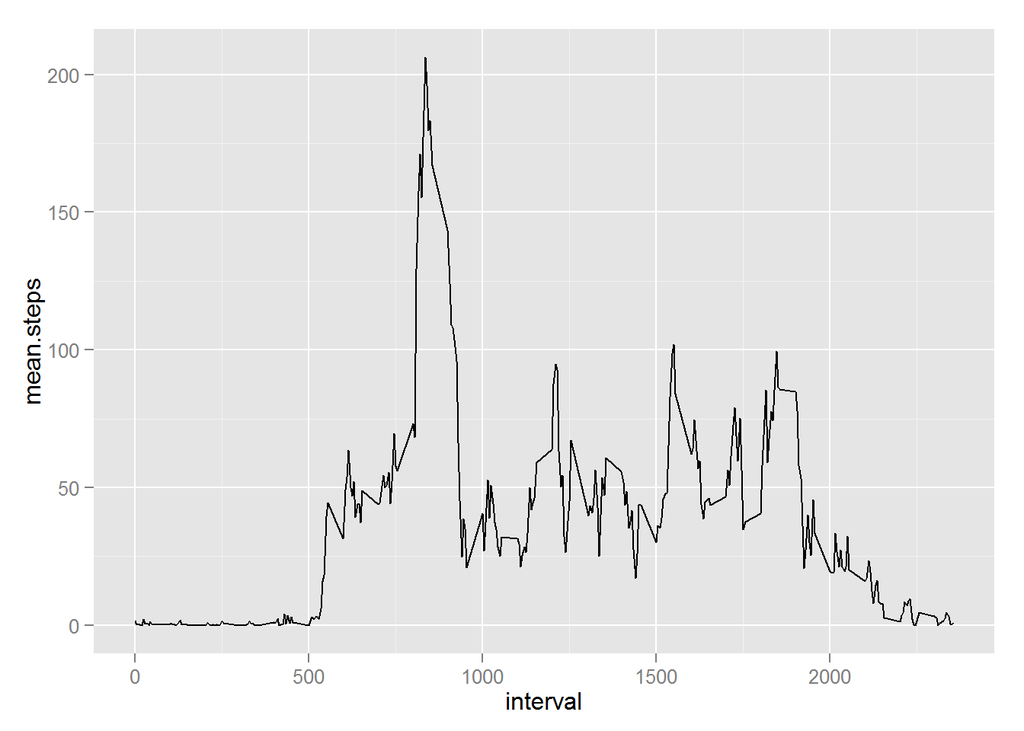

Ggplot was used to generate the graph above which displays a time series of steps taken per interval

### total number of steps per interval

assign2sum<-ddply(assign2,c(“interval”),summarize,sum.steps=sum(steps,na.rm=TRUE))

```
##   interval sum.steps
## 1        0        91
## 2        5        18
## 3       10         7
## 4       15         8
## 5       20         4
## 6       25       111
```

Use was made of the plyr package to calculate the number of steps per interval

### report the number of missing values

I ran out of time to do this part of the assignment

### imputing data

library(Amelia) a.out<-amelia(assign2,idvars=“date”)

[output not shown]

```
## -- Imputation 1 --
##
##   1  2
##
## -- Imputation 2 --
##
##   1  2
##
## -- Imputation 3 --
##
##   1  2
##
## -- Imputation 4 --
##
##   1  2
##
## -- Imputation 5 --
##
##   1  2
```

The amelia package had an easy syntax Use was made of the package to impute missing data

### new dataset with missing values filled in

assign2.i<-a.out$imputations[[5]] head(assign2.i)

```
##        steps       date interval
## 1 119.770863 2012-10-01        0
## 2 -17.952793 2012-10-01        5
## 3 -60.567201 2012-10-01       10
## 4  61.302841 2012-10-01       15
## 5 -66.344172 2012-10-01       20
## 6   7.766625 2012-10-01       25
```

It was decided to use the fifth imputation of data generated from amelia

### histogram of number of steps taken

hist(assign2.i$steps)

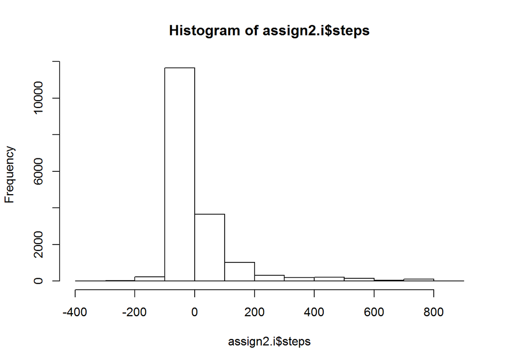

[figure not shown]

### report the mean and median of number of steps taken in imputed dataset

assign2.1meanmed<-ddply(assign2.i,c(“date”), + summarize, + mean.steps=mean(steps,na.rm=TRUE), + median.steps=median(steps,na.rm=TRUE)) head(assign2.imeanmed}

[output not shown]

Again I was unable to correctly calculate the median.

[output not shown]